# Media Sentiment on the Iran–Israel Conflict

## Model Confidence by Country

GDELT tone scores are not available via the Doc API (they are only computed in the BigQuery GKG pipeline), so cross-validation against GDELT is not possible here. As an alternative quality check, the chart below shows the distribution of BERT **prediction confidence** — the probability assigned to the winning class — for each country. High median confidence (> 0.8) indicates the model is making clear, unambiguous predictions rather than borderline calls.

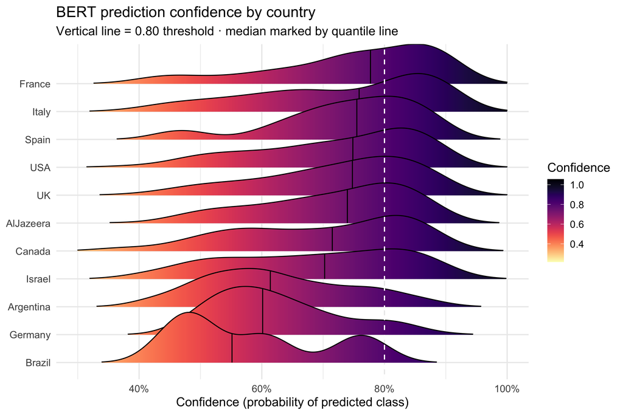

```r
df |>
  mutate(
    confidence = pmax(bert_positive, bert_neutral, bert_negative, na.rm = TRUE),
    country    = reorder(country, confidence, FUN = median, na.rm = TRUE)
  ) |>
  ggplot(aes(x = confidence, y = country, fill = after_stat(x))) +
  geom_density_ridges_gradient(scale = 1.8, rel_min_height = 0.01, quantile_lines = TRUE, quantiles = 2) +
  scale_fill_viridis(option = "magma", name = "Confidence", direction = -1) +
  scale_x_continuous(labels = percent_format(accuracy = 1), limits = c(0.3, 1)) +
  geom_vline(xintercept = 0.8, linetype = "dashed", color = "white", linewidth = 0.6) +
  labs(
    title = "BERT prediction confidence by country",
    subtitle = "Vertical line = 0.80 threshold · median marked by quantile line",
    x = "Confidence (probability of predicted class)", y = NULL
  ) +
  theme_minimal(base_size = 13)
```

## Word Clouds per Country

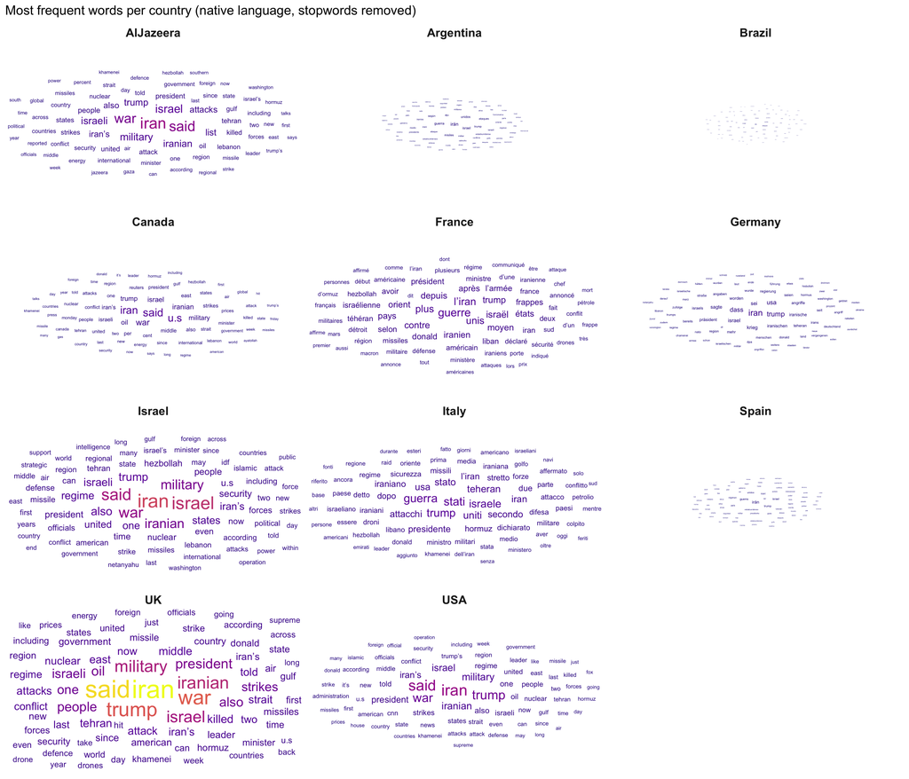

```r
top_words <- tokens_clean |>
  count(country, word, sort = TRUE) |>
  group_by(country) |>
  slice_max(n, n = 80) |>
  ungroup()

top_words |>
  ggplot(aes(label = word, size = n, color = n)) +
  geom_text_wordcloud(rm_outside = TRUE, seed = 42) +
  scale_size_area(max_size = 10) +
  scale_color_viridis_c(option = "plasma") +
  facet_wrap(~country, ncol = 3) +
  theme_minimal(base_size = 12) +
  theme(strip.text = element_text(face = "bold", size = 13)) +
  labs(title = "Most frequent words per country (native language, stopwords removed)")
```

## TF-IDF: Most Distinctive Words per Country

TF-IDF measures which words are *distinctive* to each country relative to the full corpus.

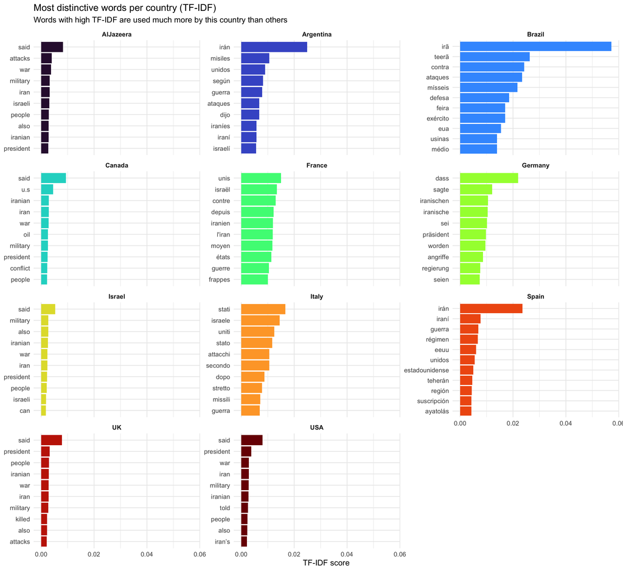

```r
tfidf <- tokens_clean |>
  count(country, word, sort = TRUE) |>
  bind_tf_idf(word, country, n) |>
  group_by(country) |>
  slice_max(tf_idf, n = 10) |>
  ungroup()

tfidf |>
  mutate(word = reorder_within(word, tf_idf, country)) |>
  ggplot(aes(x = tf_idf, y = word, fill = country)) +
  geom_col(show.legend = FALSE) +
  facet_wrap(~country, scales = "free_y", ncol = 3) +
  scale_y_reordered() +
  scale_fill_viridis_d(option = "turbo") +
  labs(
    title = "Most distinctive words per country (TF-IDF)",
    subtitle = "Words with high TF-IDF are used much more by this country than others",
    x = "TF-IDF score", y = NULL
  ) +
  theme_minimal(base_size = 11) +
  theme(strip.text = element_text(face = "bold"))
```

## Bigram Analysis

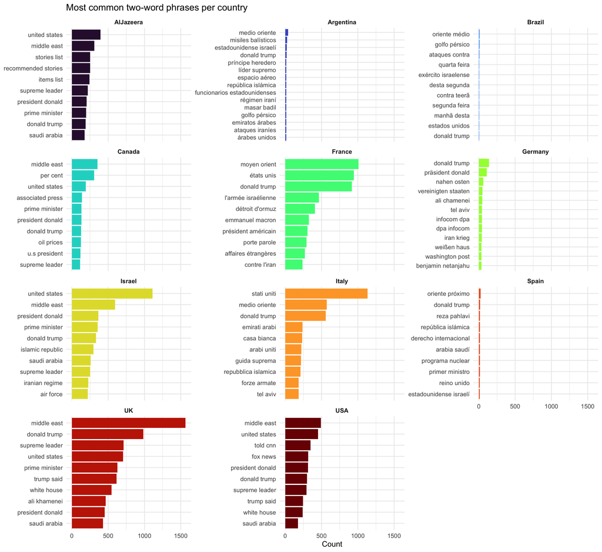

```r
bigrams <- df |>
  select(article_id, country, language, full_text) |>
  unnest_tokens(bigram, full_text, token = "ngrams", n = 2) |>
  separate(bigram, into = c("word1", "word2"), sep = " ") |>
  # Remove bigrams containing stopwords
  anti_join(all_stopwords, by = c("word1" = "word", "language")) |>
  anti_join(all_stopwords, by = c("word2" = "word", "language")) |>
  filter(nchar(word1) > 2, nchar(word2) > 2) |>
  filter(!str_detect(word1, "^\\d+$"), !str_detect(word2, "^\\d+$")) |>
  unite(bigram, word1, word2, sep = " ") |>
  count(country, bigram, sort = TRUE) |>
  group_by(country) |>
  slice_max(n, n = 10) |>
  ungroup()

bigrams |>
  mutate(bigram = reorder_within(bigram, n, country)) |>
  ggplot(aes(x = n, y = bigram, fill = country)) +
  geom_col(show.legend = FALSE) +
  facet_wrap(~country, scales = "free_y", ncol = 3) +
  scale_y_reordered() +
  scale_fill_viridis_d(option = "turbo") +
  labs(
    title = "Most common two-word phrases per country",
    x = "Count", y = NULL
  ) +
  theme_minimal(base_size = 11) +
  theme(strip.text = element_text(face = "bold"))
```

## Weekly Sentiment Trends by Country

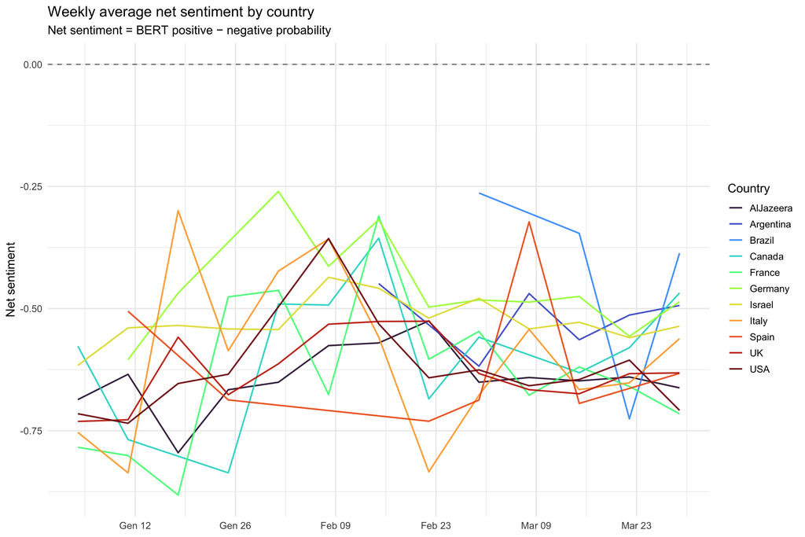

```r
weekly <- df |>
  group_by(country, week) |>
  summarise(
    net = mean(bert_net, na.rm = TRUE),
    n   = n(),
    .groups = "drop"
  )

p <- weekly |>
  ggplot(aes(x = week, y = net, color = country, group = country)) +
  geom_line(linewidth = 0.8, alpha = 0.9) +
  geom_hline(yintercept = 0, linetype = "dashed", color = "grey50") +
  scale_color_viridis_d(option = "turbo", name = "Country") +
  scale_x_date(date_breaks = "2 weeks", date_labels = "%b %d") +
  labs(
    title = "Weekly average net sentiment by country",
    subtitle = "Net sentiment = BERT positive − negative probability",
    x = NULL, y = "Net sentiment"
  ) +
  theme_minimal(base_size = 13) +
  theme(legend.position = "right")

# Add event annotations if any exist
if (nrow(events) > 0) {
  p <- p +
    geom_vline(
      data = events,
      aes(xintercept = date),
      linetype = "dotted", color = "firebrick", linewidth = 0.7
    ) +
    annotate(
      "text",
      x = events$date,
      y = max(weekly$net, na.rm = TRUE) * 0.9,
      label = events$label,
      angle = 90, hjust = 1, size = 3, color = "firebrick"
    )
}

p
```

## 7-Day Rolling Average by Country

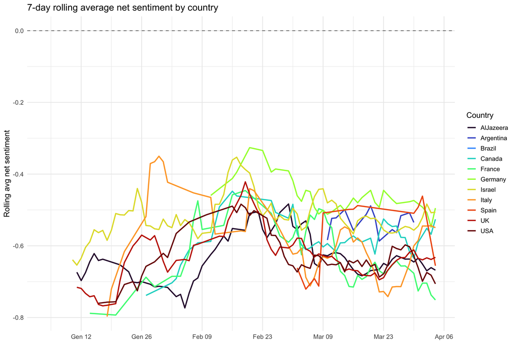

```r
daily <- df |>
  group_by(country, published_date) |>
  summarise(net = mean(bert_net, na.rm = TRUE), .groups = "drop") |>
  arrange(country, published_date) |>
  group_by(country) |>
  mutate(rolling_net = rollmean(net, k = 7, fill = NA, align = "right")) |>
  ungroup()

daily |>
  ggplot(aes(x = published_date, y = rolling_net, color = country)) +
  geom_line(linewidth = 1, na.rm = TRUE) +
  geom_hline(yintercept = 0, linetype = "dashed", color = "grey50") +
  scale_color_viridis_d(option = "turbo", name = "Country") +
  scale_x_date(date_breaks = "2 weeks", date_labels = "%b %d") +
  labs(
    title = "7-day rolling average net sentiment by country",
    x = NULL, y = "Rolling avg net sentiment"
  ) +
  theme_minimal(base_size = 13)
```